# Quiz 6

## INSTRUCTIONS:

Any potential violation of Georgetown’s policy on academic integrity will be reported. All work on this exam must be your own. You are not allowed to communicate or gain information in any way from your classmates or seek outside human help on the exam. If you are using online resources always cite the sources (and/or include the links).

You need to SHOW YOUR WORK in order to get full credits. __________________________________________________________________________

## Problem: Linear Regression (*105 points*)

In the last Quiz, you compared Kelly Clarkson’s music with Arianna Grande’s music. We will extend this analysis by fitting linear regression model for the data: “Ariana_grande.csv”.

```r
library(dplyr)
df <- read.csv('Arianna_grande.csv')
```

## Data science question

1. (*5 points*) Formulate your Data Science question?

   *Data Science Question: What are the variables contributing for predicting “………….” of the songs of musician; Arianna Grande.*

   You have to choose the response variable of your choice. (Please indicate why you chose this variable as the response variable)

Data science question: which variables contribute to the predictability of the energy of a song by Ariana Grande?

I chose energy as the response variable because I think it’s the most likely to be affected by other variables. I’d expect the energy of a song to be dependent on its danceability, tempo, key, etc. We tend to see higher energy in songs that are dance-oriented, songs with brighter keys, etc., so I wanted to explore the belief that energy could be predicted on these variables.

## Linear regression fit

2. Fit a linear regression model for Artist: *Ariana Grande* , to find what variables contributes on predicting your response variable.
   1. (*10 points*) Remember to train your model on a training set and validate the model using a validation set.
   2. (*5 points*) Also remember, data cleaning is also a part of this assignment. You may have to remove a few unnecessary variables from this data set(for example: aritist_name,artist_id,..etc) for this analysis, but if you do, please justify why you removed them.
   3. (*15 points*) Remember you are fitting a FULL model with all the variables(except above mentioned unnecessary variables) and also check for interactions.

### Removing unwanted variables

```r
# keep wanted variables
vars <- c('ag.danceability', 'ag.energy', 'ag.key', 'ag.loudness', 'ag.speechiness', 'ag.acousticness', 'ag.instrumentalness', 'ag.liveness', 'ag.valence', 'ag.tempo', 'ag.duration_ms')

# put the clean data into a new df
df.clean <- df[, vars]
```

### split data into train and test sets

I decided to split the data with a ratio of 7:3.

```r
set.seed(42)
smp_size <- floor(0.7 * nrow(df.clean))
train_ind <- sample(seq_len(nrow(df.clean)), size = smp_size)
train <- df.clean[train_ind, ]
test <- df.clean[-train_ind, ]
```

### fit the model and check the parameter weights

```r
fit <- lm(ag.energy ~., data = train)
summary(fit)
```

```
##
## Call:
## lm(formula = ag.energy ~ ., data = train)
##
## Residuals:
##       Min        1Q    Median        3Q       Max
## -0.203616 -0.064798  0.001762  0.056504  0.266978
##
## Coefficients:
##                       Estimate Std. Error t value Pr(>|t|)
## (Intercept)          8.390e-01  6.230e-02  13.468  < 2e-16 ***
## ag.danceability      9.585e-02  4.950e-02   1.936 0.053788 .
## ag.key              -1.451e-03  1.517e-03  -0.957 0.339456
## ag.loudness          5.255e-02  3.777e-03  13.911  < 2e-16 ***
## ag.speechiness       2.748e-01  6.870e-02   4.001 8.00e-05 ***
## ag.acousticness     -2.695e-01  2.436e-02 -11.064  < 2e-16 ***
## ag.instrumentalness  1.323e-01  8.910e-02   1.485 0.138582
## ag.liveness          1.487e-01  2.543e-02   5.847 1.33e-08 ***
## ag.valence           1.107e-01  3.170e-02   3.491 0.000555 ***
## ag.tempo             9.206e-05  2.249e-04   0.409 0.682581
## ag.duration_ms      -1.102e-07  1.227e-07  -0.898 0.369854
## ---
## Signif. codes:  0 '***' 0.001 '**' 0.01 '*' 0.05 '.' 0.1 ' ' 1
##
## Residual standard error: 0.08979 on 294 degrees of freedom
## Multiple R-squared:  0.7403, Adjusted R-squared:  0.7314
## F-statistic: 83.79 on 10 and 294 DF,  p-value: < 2.2e-16
```

## Analyzing variable relationships

3. (*10 points*) Do you see any in-significant variables? What are the variables that contribute to predicting your response variable?

According to the fit summary, tempo, duration_ms, instrumentalness, and key are insignificant variables. Out of these, I’m only surprised that tempo doesn’t influence the energy of a song. My guess would’ve been that the higher a tempo, the higher the energy.

The variables that can contribute to my response variable are danceability, loudness, speechiness, acousticness, liveness, and valence. I know this because they all have a p-value smaller than 0.05; danceability has a score slightly over the threshold, so I will still include it in the next model for prediction.

## Fitting a better model

4. (*10 points*) Can you fit a better model? Fit a new model by removing these in-significant variables (but remember the hierarchy principle). Also remember to check for multicollinearity. Explain.

```r
# keeping the variables we want
vars2 <- c('ag.energy', 'ag.danceability', 'ag.loudness', 'ag.speechiness', 'ag.acousticness', 'ag.liveness', 'ag.valence')

# put the clean data into a new df
df.clean2 <- df[, vars2]

# train test split
set.seed(42)
smp_size <- floor(0.7 * nrow(df.clean2))
train_ind <- sample(seq_len(nrow(df.clean2)), size = smp_size)
train2 <- df.clean2[train_ind, ]
test2 <- df.clean2[-train_ind, ]

# fit the model
fit2 <- lm(ag.energy ~ ., data = train2)
summary(fit2)
```

```
##
## Call:
## lm(formula = ag.energy ~ ., data = train2)
##
## Residuals:
##       Min        1Q    Median        3Q       Max
## -0.195618 -0.071388  0.006163  0.057033  0.273538
##
## Coefficients:
##                  Estimate Std. Error t value Pr(>|t|)
## (Intercept)      0.799295   0.035855  22.292  < 2e-16 ***
## ag.danceability  0.111869   0.048291   2.317 0.021207 *
## ag.loudness      0.050781   0.003631  13.984  < 2e-16 ***
## ag.speechiness   0.278474   0.067981   4.096 5.41e-05 ***
## ag.acousticness -0.272238   0.023148 -11.761  < 2e-16 ***
## ag.liveness      0.151133   0.025282   5.978 6.45e-09 ***
## ag.valence       0.112859   0.031622   3.569 0.000417 ***
## ---
## Signif. codes:  0 '***' 0.001 '**' 0.01 '*' 0.05 '.' 0.1 ' ' 1
##
## Residual standard error: 0.08979 on 298 degrees of freedom
## Multiple R-squared:  0.7367, Adjusted R-squared:  0.7314
## F-statistic:   139 on 6 and 298 DF,  p-value: < 2.2e-16
```

The new model, with less variables, gave us an almost identical score as the previous model. I would assume that this is likely due to the removed variables having contributed basically nothing to the first predictive model.

```r
# multicollinearity
library(car)
set.seed(42)
vif(fit2)
```

```
## ag.danceability     ag.loudness  ag.speechiness ag.acousticness     ag.liveness
##        1.420422        1.331062        1.040770        1.318146        1.027656
##      ag.valence
##        1.450248
```

With all vif scores being under 1.5, I feel comfortable keeping them in the regression, given that they’re not highly correlated. I will try another model that takes into account the interactions between the variables.

```r
fit3 <- lm(ag.energy ~ (.)^2, data=train2)
summary(fit3)
```

```
##
## Call:
## lm(formula = ag.energy ~ (.)^2, data = train2)
##
## Residuals:
##       Min        1Q    Median        3Q       Max
## -0.213543 -0.049694 -0.001325  0.049478  0.246045
##
## Coefficients:
##                                  Estimate Std. Error t value Pr(>|t|)
## (Intercept)                      0.742605   0.167161   4.442 1.28e-05 ***
## ag.danceability                  0.244837   0.274075   0.893  0.37244
## ag.loudness                      0.032903   0.022133   1.487  0.13823
## ag.speechiness                   0.889869   0.437515   2.034  0.04289 *
## ag.acousticness                 -0.990306   0.125586  -7.885 6.85e-14 ***
## ag.liveness                      0.009232   0.147079   0.063  0.95000
## ag.valence                       0.407982   0.212114   1.923  0.05543 .
## ag.danceability:ag.loudness      0.019610   0.036506   0.537  0.59156
## ag.danceability:ag.speechiness  -1.140177   0.613021  -1.860  0.06393 .
## ag.danceability:ag.acousticness  0.588960   0.191246   3.080  0.00228 **
## ag.danceability:ag.liveness      0.041088   0.238869   0.172  0.86355
## ag.danceability:ag.valence      -0.273069   0.264634  -1.032  0.30301
## ag.loudness:ag.speechiness       0.164425   0.047803   3.440  0.00067 ***
## ag.loudness:ag.acousticness     -0.034908   0.010881  -3.208  0.00149 **
## ag.loudness:ag.liveness         -0.022766   0.016717  -1.362  0.17434
## ag.loudness:ag.valence           0.024896   0.016342   1.523  0.12877
## ag.speechiness:ag.acousticness   2.363989   0.410185   5.763 2.15e-08 ***
## ag.speechiness:ag.liveness       0.212095   0.387161   0.548  0.58425
## ag.speechiness:ag.valence        0.882202   0.508425   1.735  0.08380 .
## ag.acousticness:ag.liveness      0.066499   0.175936   0.378  0.70573
## ag.acousticness:ag.valence       0.020876   0.130213   0.160  0.87274
## ag.liveness:ag.valence          -0.131976   0.154911  -0.852  0.39496
## ---
## Signif. codes:  0 '***' 0.001 '**' 0.01 '*' 0.05 '.' 0.1 ' ' 1
##
## Residual standard error: 0.07845 on 283 degrees of freedom
## Multiple R-squared:  0.8091, Adjusted R-squared:  0.7949
## F-statistic: 57.12 on 21 and 283 DF,  p-value: < 2.2e-16
```

Since this model has better results than the first two, I’ll make one last attempt using the variables deemed important by this model.

```r
fit4 <- lm(ag.energy ~ ag.speechiness + ag.acousticness + ag.valence + ag.danceability*ag.acousticness + ag.loudness*ag.speechiness + ag.loudness*ag.acousticness + ag.speechiness*ag.acousticness, data=train2)
summary(fit4)
```

```
##
## Call:
## lm(formula = ag.energy ~ ag.speechiness + ag.acousticness + ag.valence +
##     ag.danceability * ag.acousticness + ag.loudness * ag.speechiness +
##     ag.loudness * ag.acousticness + ag.speechiness * ag.acousticness,
##     data = train2)
##
## Residuals:
##       Min        1Q    Median        3Q       Max
## -0.223268 -0.053150 -0.003142  0.054973  0.236909
##
## Coefficients:
##                                  Estimate Std. Error t value Pr(>|t|)
## (Intercept)                      1.008951   0.047809  21.104  < 2e-16 ***
## ag.speechiness                   1.122904   0.260439   4.312 2.21e-05 ***
## ag.acousticness                 -1.147920   0.115188  -9.966  < 2e-16 ***
## ag.valence                       0.143179   0.030225   4.737 3.37e-06 ***
## ag.danceability                 -0.130329   0.059945  -2.174   0.0305 *
## ag.loudness                      0.051557   0.005882   8.765  < 2e-16 ***
## ag.acousticness:ag.danceability  0.736825   0.167726   4.393 1.56e-05 ***
## ag.speechiness:ag.loudness       0.230911   0.045719   5.051 7.73e-07 ***
## ag.acousticness:ag.loudness     -0.053024   0.009061  -5.852 1.29e-08 ***
## ag.speechiness:ag.acousticness   1.908416   0.340615   5.603 4.84e-08 ***
## ---
## Signif. codes:  0 '***' 0.001 '**' 0.01 '*' 0.05 '.' 0.1 ' ' 1
##
## Residual standard error: 0.08287 on 295 degrees of freedom
## Multiple R-squared:  0.778,  Adjusted R-squared:  0.7712
## F-statistic: 114.9 on 9 and 295 DF,  p-value: < 2.2e-16
```

It would appear that our best scores came from the third model.

## Compare model performances

5. (*10 points*) Which model is the better model? (part b or d?) Justify your answer by comparing the model (b) and model (d) using $R^2$, $RSE$, $RMSE$ and $F-statistic$.?

```r
library(caret)
# fit
predictions1 <- fit %>% predict(test)
p1=data.frame(
  RMSE = RMSE(predictions1, test$ag.danceability),
  R2 = R2(predictions1, test$ag.danceability)
)
# fit2
predictions2 <- fit2 %>% predict(test2)
p2=data.frame(
  RMSE = RMSE(predictions2, test2$ag.danceability),
  R2 = R2(predictions2, test2$ag.danceability)
)
# fit3
predictions3 <- fit3 %>% predict(test2)
p3=data.frame(
  RMSE = RMSE(predictions3, test2$ag.danceability),
  R2 = R2(predictions3, test2$ag.danceability)
)
# Mfit4
predictions4 <- fit4 %>% predict(test2)
p4=data.frame(
  RMSE = RMSE(predictions4, test2$ag.danceability),
  R2 = R2(predictions4, test2$ag.danceability)
)

# summary statistics
all =rbind(p1,p2,p3,p4)
all=cbind(all, c(summary(fit)$fstatistic[1], summary(fit2)$fstatistic[1], summary(fit3)$fstatistic[1], summary(fit4)$fstatistic[1]))
all=cbind(all,c(summary(fit)$adj.r.squared, summary(fit2)$adj.r.squared, summary(fit3)$adj.r.squared, summary(fit4)$adj.r.squared))
all=cbind(all,c(summary(fit)$sigma, summary(fit2)$sigma, summary(fit3)$sigma, summary(fit4)$sigma))
all = cbind(all, c('fit1','fit2','fit3','fit4'))
colnames(all)[c(3,4,5,6)]<-c("F stat","Adj Rˆ2", "RSE","models")
all
```

```
##        RMSE        R2    F stat   Adj Rˆ2        RSE models
## 1 0.1555245 0.2401493  83.79112 0.7314277 0.08978595   fit1
## 2 0.1550421 0.2403308 138.97405 0.7314118 0.08978861   fit2
## 3 0.1512569 0.2058394  57.12191 0.7949493 0.07845280   fit3
## 4 0.1452304 0.2610530 114.85950 0.7712110 0.08286961   fit4
```

## Best predictors

6. (*10 points*) What predictors contributes more to your response variable (Use the best model you choose from d)? What can you tell about what you observe from this whole analysis and what you have known about her music? Are there any contrasting factors?

- ag.speechiness
- ag.acousticness
- ag.valence
- ag.danceability
- ag.loudness
- ag.acousticness:ag.danceability
- ag.speechiness:ag.loudness
- ag.acousticness:ag.loudness
- ag.speechiness:ag.acousticness

I expected the variables listed here, that come from the original data frame, to have an important influence on the song’s energy. I think valence, danceability, and loudness specifically would’ve had a big effect on the energy variable, so I was happy to see them come out as significant predictors. For the additional variables that take into account interactions between all variables, I selected the ones listed above. I’m still a bit unsure about how these interactions work, but it improved the model, so I’m happy with the outcome. I don’t know her music well and can’t talk to that part of the question, but I surmise that the relationships we see in this regression model would show up in all types of music and not just hers. The only unsusual variable in my opinion is the speechiness one. With electronic music being some of the most energetic, I thought speechiness shouldn’t affect the energy scores.

## Comparing to previous quiz

7. (*5 points*) Does this give you any new results to support what you observe in the last Quiz when you were analyzing this data? Explain.

In the previous quiz I compared Ariana’s and Kelly’s danceability scores and found that Ariana’s music, on average, has a significantly higher danceability score. If the predictors hold true across artists, I would then look at the correlations that my predictive variables have to the target variable (positive or negative) and make inferences about the scores that I should see for Kelly Clarkson. For example, if energy has a high correlation with danceability, I would expect to see Ariana Grande have a higher average energy than Kelly Clarkson; I could repeat the experiment with all significant variables found in model with Fit 4.

## Is linear model good

8. (*10 points*) Is a linear model adequate for this data? Justify your answer.

## Outliers

1. (*10 points*) Please identify outliers, leverage points and high leverage points using residual plots (if there are any).

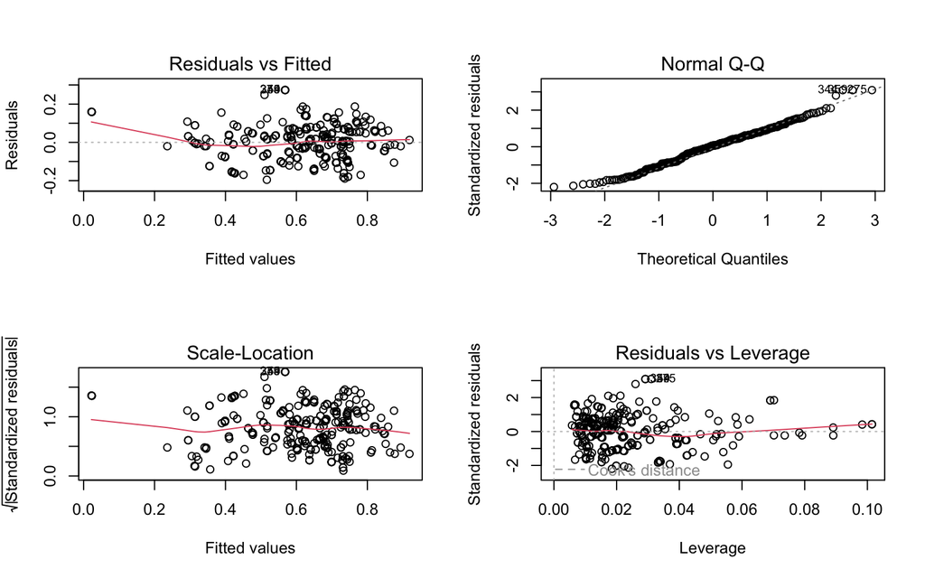

```r
par(mfrow=c(2,2))
plot(fit2)
```

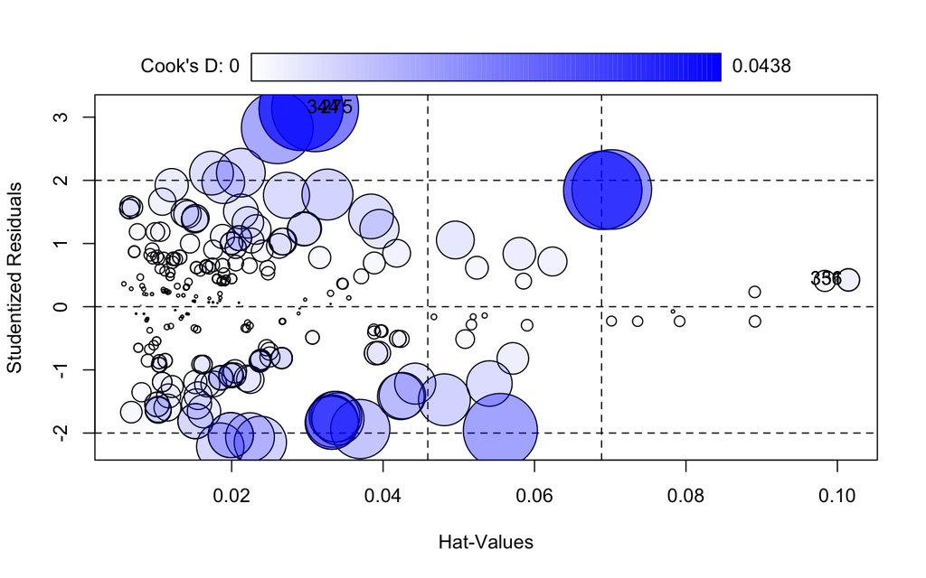

```
##       StudRes        Hat       CookD
## 344 3.1374269 0.02916639 0.041028575
## 336 0.4243449 0.10145304 0.002912465
## 275 3.1398394 0.03102267 0.043788531
## 351 0.4243449 0.10145304 0.002912465
```

```r
(outs <- influencePlot(fit2))
```